# Speedating - Differences between Men & Women

Manda, Rosa, & Jamie

## Introduction

In 2002-2004, there was data collected for 21 different speed-dating outings with different individuals. Data was collected about each persons’s income, religious background, career, favorite hobbies, race, and ratings on how each individual believes they are perceived by others.

After each speed-dating outing, each individual was asked whether they wanted to match with the individuals they met. Additionally, they were asked to rate the people they met on a variety of traits (ambitious, attractive, sincere, fun, intelligent, etc.). In this analysis, we explored and assesed the factors that most significantly influence a person’s decision to “match” with others.

## Correlations

To start, we wanted to see if there were correlations between interests of participants and the interests of the partner they requested to be matched to. Below are the various speed-dating outings (which vary in size) and the interest correlations of those who said “yes” to being matched.

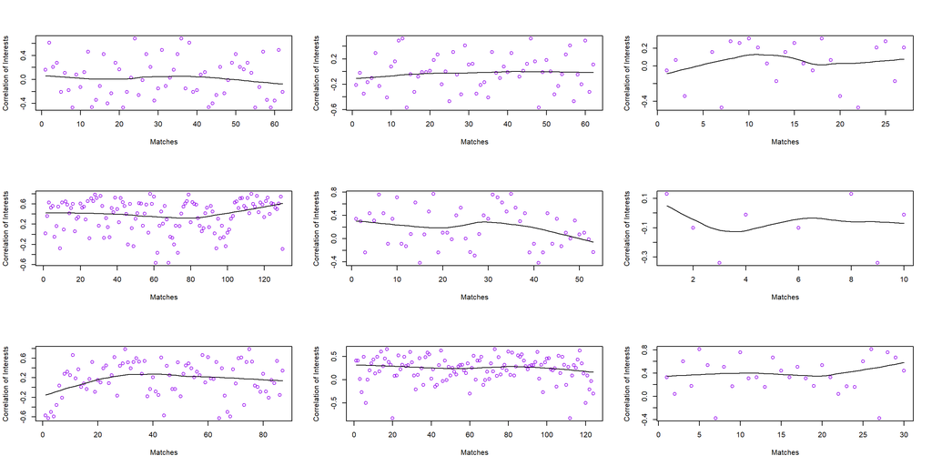

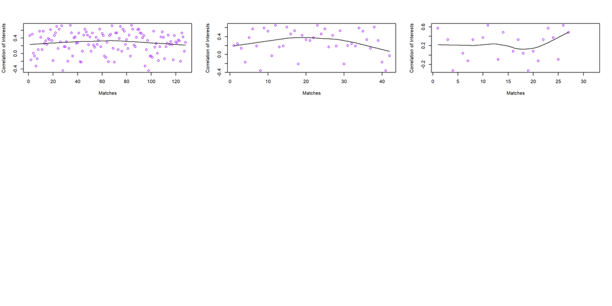

## Careers of those who were Matched and Not-Matched

Since there was a variety of differences in the interest correlations, we wanted to explore what made someone say “yes”. So, we asked ourselves what are the factors that influence a woman to say “yes” to being matched after only 4 minutes.

First, we filtered the data by women who said “yes” to being matched, and then looked at the careers of the men they asked to be matched with. Then we commpared that graph to women who said “no” to being matched and the careers of the men who they rejected. We plotted the “yes” & “no” matches against an attribute ranking (out of 10) that was given by partners at the speed-dating outing.

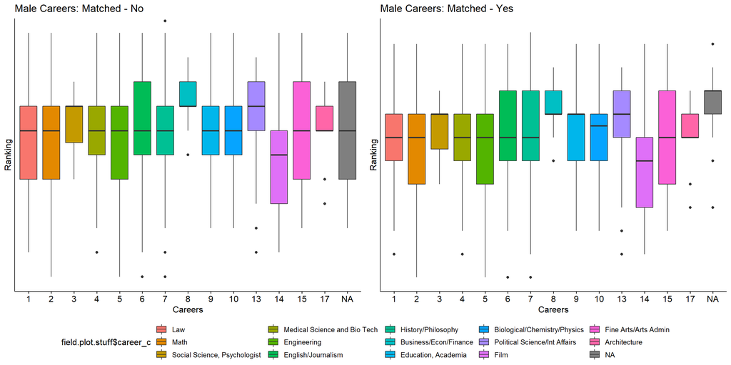

## Hobbies: Differences between a 0/10 and 10/10.

After plotting the “yes” and “no” of men with their careers and rankings, we saw that there were men who were ranked 0/10, 1/10 and those who were ranked 9/10 and 10/10. Naturally, we wanted to know who these men were. For the men who received these rankings we asked, “why are you the way that you are?”

We grouped the data for men who were 0/10 and 1/10 and for men who were 9/10 and 10/10. After grouping the data we plotted their hobbies/interests against the rankings they received for these traits so we could determine if their was a large difference in hobbies between those who were given a 0 and those who were given a 10. Once again, these rankings were out of 10.

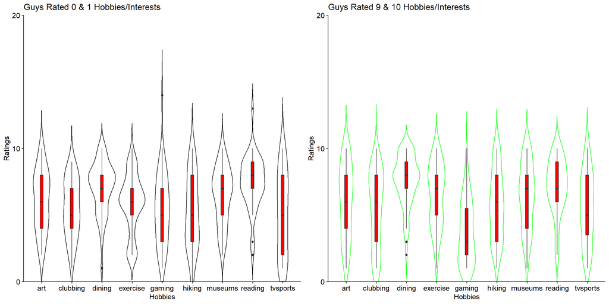

## Personality: What Women Say They Want

Before the speed-dating outing, women were asked to rate what their preference for what they were looking for. They had 100 points to distribute among the personality attributes, and they were asked to givie more points to those attributes that were more important in a potential date, and fewer points to those attributes that were less important in a potential date. Total points must equal 100.

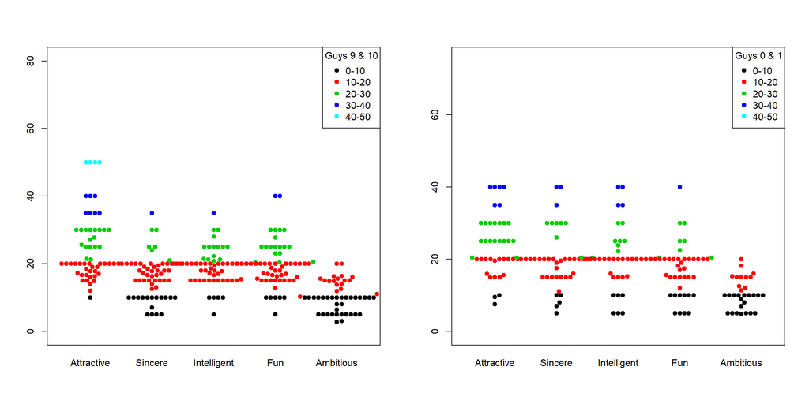

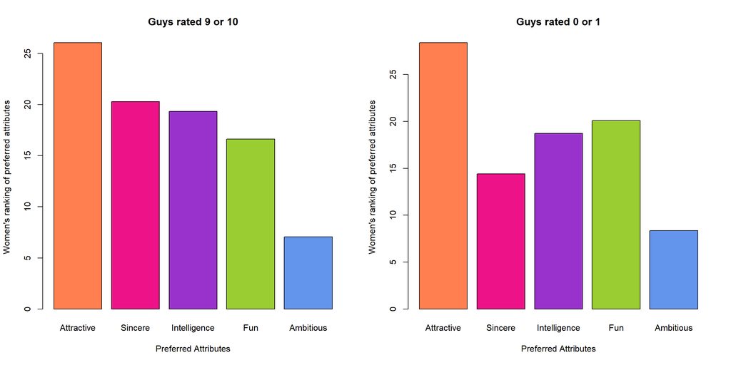

## Personality: Differences between a 0/10 and 10/10.

There wasn’t much difference between hobbies/interests of the men, so we moved on to the personality differences. Perhaps there were certain personalities of men that women weren’t attracted to within the short four minute time span of the speed-dating process. We measured the differences between guys ranked 0 & 1 out of 10 and those ranked 9 & 10 out of 10. The rankings used here are ratings by the partner the night of the event.

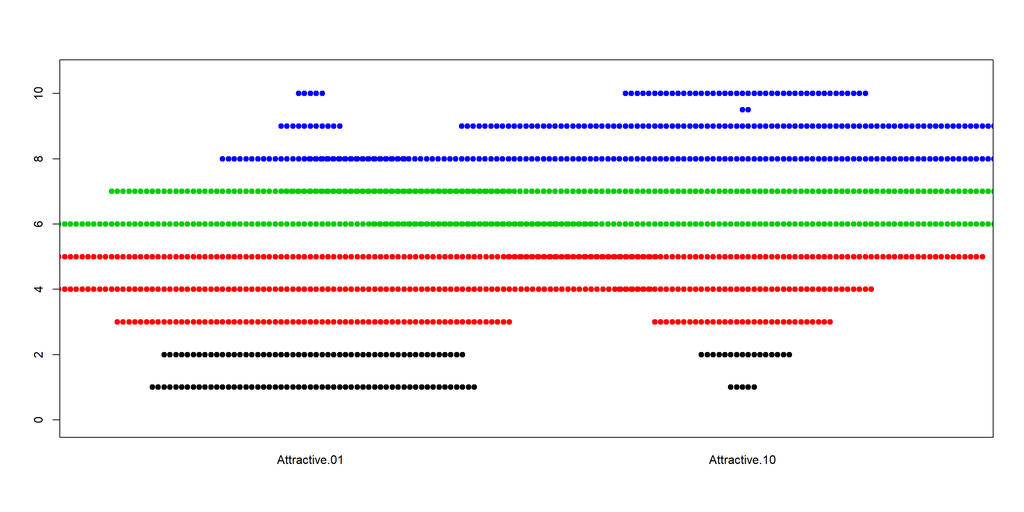

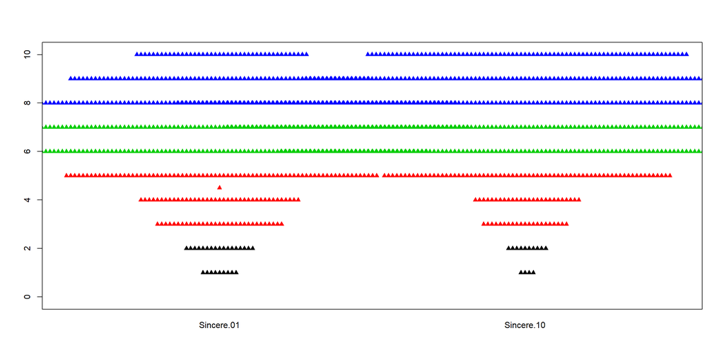

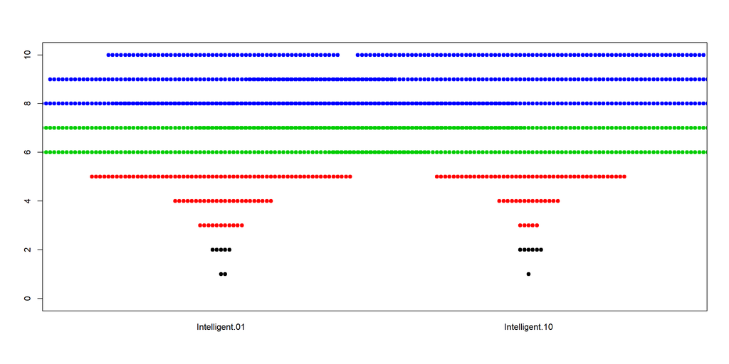

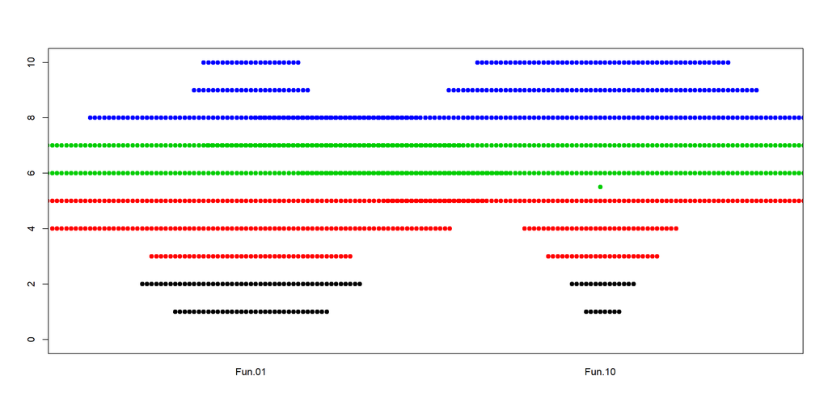

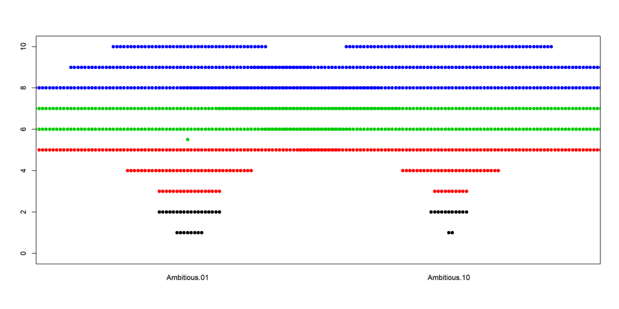

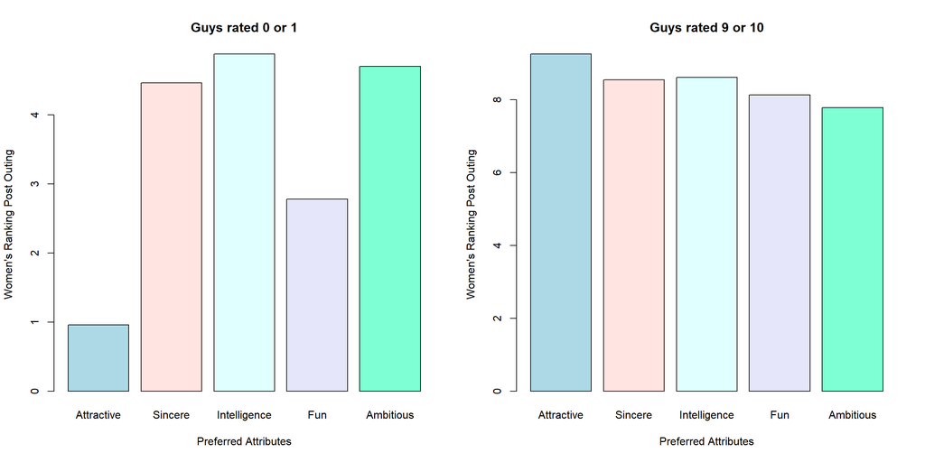

## Who is #12??

```
Career: Laywer
Race: Caucassian
Age: 22
From: England
Income: 29,237.00
```

| hobbies1 | ratings1 |
| --- | --- |
| tvsports | 7 |
| exercise | 9 |
| dining | 8 |
| museums | 7 |
| art | 6 |
| hiking | 3 |
| gaming | 3 |
| clubbing | 5 |
| reading | 6 |

## What about race? Are people more inclined to date their same race?

We’ve looked at careers, hobbies/interests, and personality traits. What else could factor into somone’s decision in the short time span they meet someone during the speed-dating outing? Perhaps race is a big factor in the decision. So we looked at all the matches and compared the race of the matched couples.

Black/African American=1 European/Caucasian-American=2 Latino/Hispanic American=3 Asian/Pacific Islander/Asian-American=4 Native American=5 Other=6

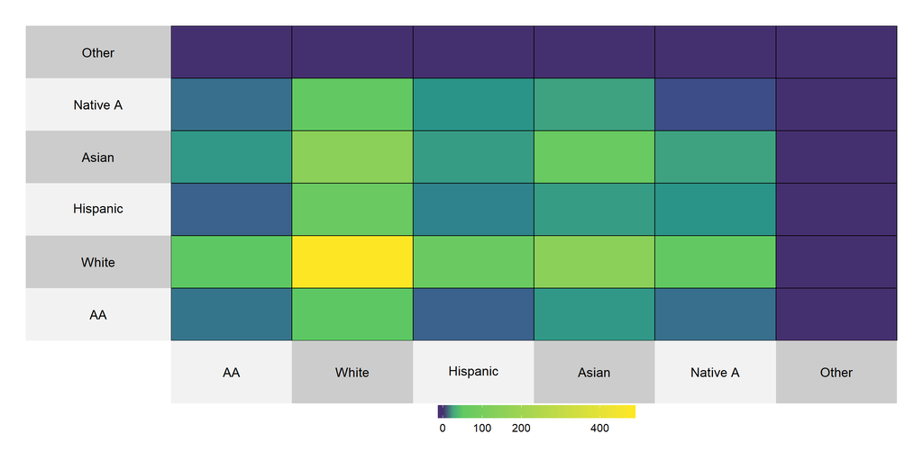

## Women and Men on Personalities: Part 1

Once we viewed the difference in personalities of men who were ranked differently, we then asked ourselves what the differences are between men’s and women’s personalities. In this graph, the “ranking” data is from the survey where both men and women rate what traits are important to them. The sum of the score must equal 100.

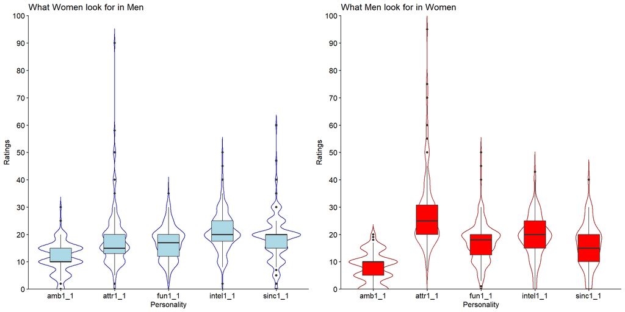

## Women and Men on Personalities: Part 2

We wanted a better picture of the overlap of desired personality traits of men and women, so we created the web-overlap graph to obtain a better idea of the similarites and differences between desired traits.

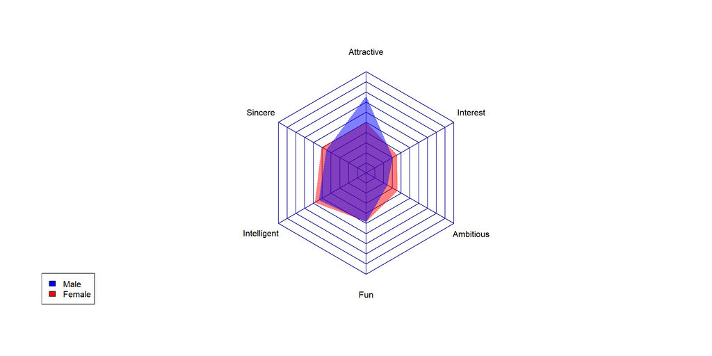

## In Conclusion

Manda produced the violin plot graphs,beeswarm graphs, and boxplot graphs, code and participated in the summary of the presenation. Rosa produced the figures and code for the superheat graph and the spiderweb graph, was valuable in checking the other code and graphs for errors, and also participated in the writing of the summary. Jamie created the “average ranking” plots so we could view the proportions correctly. She was instrumental in checking our code, analysis, and thought-process as we worked to find the information we were wanting to portray (since it was very easy to make mistakes with similar variables). Jamie also did the analysis and write-up of our results.